# NYPD Shooting Report Demographics

Adam McKeeby

9/15/2021

#### Pull down CSV file

```r
nypd_url  <- "https://data.cityofnewyork.us/api/views/833y-fsy8/rows.csv?accessType=DOWNLOAD"
nypd_csv <- read_csv(nypd_url, col_select = c("OCCUR_DATE", "OCCUR_TIME", "PERP_AGE_GROUP", "PERP_SEX", "PERP_RACE", "VIC_AGE_GROUP", "VIC_SEX", "VIC_RACE"))
```

#### Tidy up data

```r
nypd_csv[nypd_csv==""] <- "UNKNOWN"
nypd_csv[is.na(nypd_csv)] <- "UNKNOWN"
formattedCSV <- nypd_csv %>%
    mutate(OCCUR_DATE = mdy(OCCUR_DATE), OCCUR_TIME = hms(OCCUR_TIME)) %>%
    mutate(P_AGE_GROUP = recode(PERP_AGE_GROUP,"<18" = 1,"18-24" = 2, "25-44" = 3, "45-64" = 4, "65+" = 5, .default = -1)) %>%
    mutate(V_AGE_GROUP = recode(VIC_AGE_GROUP,"<18" = 1,"18-24" = 2, "25-44" = 3, "45-64" = 4, "65+" = 5, .default = -1)) %>%
    mutate(MONTH = month(OCCUR_DATE))
filteredCSV <- filter(formattedCSV, V_AGE_GROUP > 0)
filteredCSV <- filter(filteredCSV, P_AGE_GROUP > 0)
filteredCSV <- filter(filteredCSV, PERP_SEX %in% c("M", "F"))
filteredCSV <- filter(filteredCSV, VIC_SEX %in% c("M", "F"))
filteredCSV["Perp_vs_Vic"] <- case_when(
  filteredCSV["P_AGE_GROUP"] < filteredCSV["V_AGE_GROUP"] ~ "LESS",
  filteredCSV["P_AGE_GROUP"] > filteredCSV["V_AGE_GROUP"] ~ "GREATER",
  filteredCSV["P_AGE_GROUP"] %% filteredCSV["V_AGE_GROUP"] == 0 ~ "SAME",
)

filteredCSV["PerpSex_vs_VicSex"] <- case_when(
  filteredCSV["PERP_SEX"]  == "M" & filteredCSV["VIC_SEX"] == "M" ~ "Male->Male",
  filteredCSV["PERP_SEX"] == "M" & filteredCSV["VIC_SEX"] == "F" ~ "Male->Female",
  filteredCSV["PERP_SEX"] == "F" & filteredCSV["VIC_SEX"] == "F" ~ "Female->Female",
  filteredCSV["PERP_SEX"] == "F" & filteredCSV["VIC_SEX"] == "M" ~ "Female->Male",
)
summary(filteredCSV)
```

```
##    OCCUR_DATE           OCCUR_TIME                        PERP_AGE_GROUP
##  Min.   :2006-01-01   Min.   :0S                          Length:11864
##  1st Qu.:2008-09-28   1st Qu.:3H 55M 0S                   Class :character
##  Median :2011-12-31   Median :15H 24M 30S                 Mode  :character
##  Mean   :2012-08-04   Mean   :12H 59M 21.7464598786246S
##  3rd Qu.:2016-01-11   3rd Qu.:20H 29M 0S
##  Max.   :2020-12-29   Max.   :23H 59M 0S
##    PERP_SEX          PERP_RACE         VIC_AGE_GROUP        VIC_SEX
##  Length:11864       Length:11864       Length:11864       Length:11864
##  Class :character   Class :character   Class :character   Class :character
##  Mode  :character   Mode  :character   Mode  :character   Mode  :character
##
##
##
##    VIC_RACE          P_AGE_GROUP     V_AGE_GROUP        MONTH
##  Length:11864       Min.   :1.000   Min.   :1.000   Min.   : 1.000
##  Class :character   1st Qu.:2.000   1st Qu.:2.000   1st Qu.: 4.000
##  Mode  :character   Median :2.000   Median :3.000   Median : 7.000
##                     Mean   :2.365   Mean   :2.496   Mean   : 6.679
##                     3rd Qu.:3.000   3rd Qu.:3.000   3rd Qu.: 9.000
##                     Max.   :5.000   Max.   :5.000   Max.   :12.000
##  Perp_vs_Vic        PerpSex_vs_VicSex
##  Length:11864       Length:11864
##  Class :character   Class :character
##  Mode  :character   Mode  :character
##
##
##
```

### Research Questions:

#### Question 1:

In the NYPD shooting data, what sex is most likely to be the shooter and what sex is the victim?

#### Hypothesis 1:

- If a shooting is reported by/to the NYPD, the shooter will most likely be male and the victim has an equal chance of being male or female.

#### Distribution of sex demographic in shooting data:

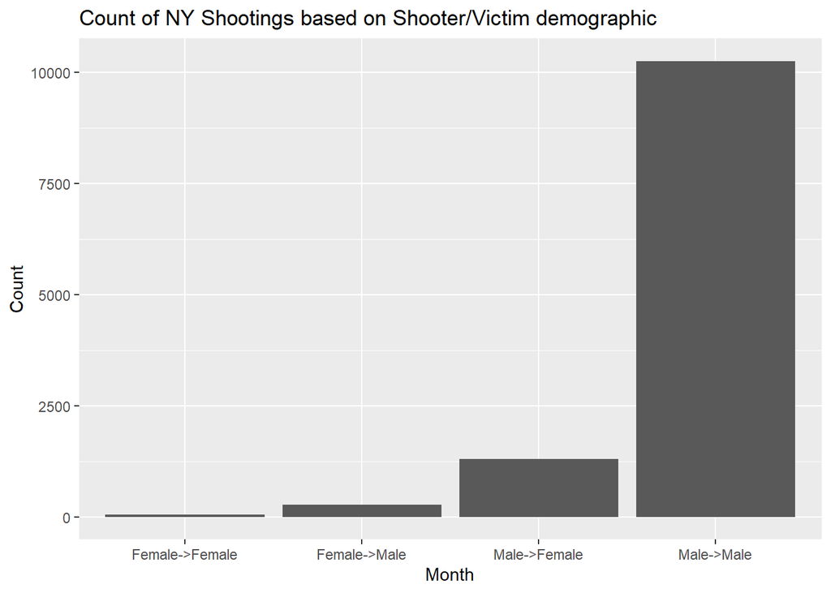

```r
ggplot(data = filteredCSV, mapping = aes(x=PerpSex_vs_VicSex),) +
  geom_bar( stat="count") +
  labs(title = "Count of NY Shootings based on Shooter/Victim demographic") +
  ylab("Count") + xlab("Month")
```

#### Question 2:

Does the amount of shootings that occur vary over the course of the year or is it relatively constant?

#### Hypothesis 2:

- Over the course of the year, shootings across the Shooter/Victim combinations will be relatively constant.

#### Distribution of sex demographic in shooting data:

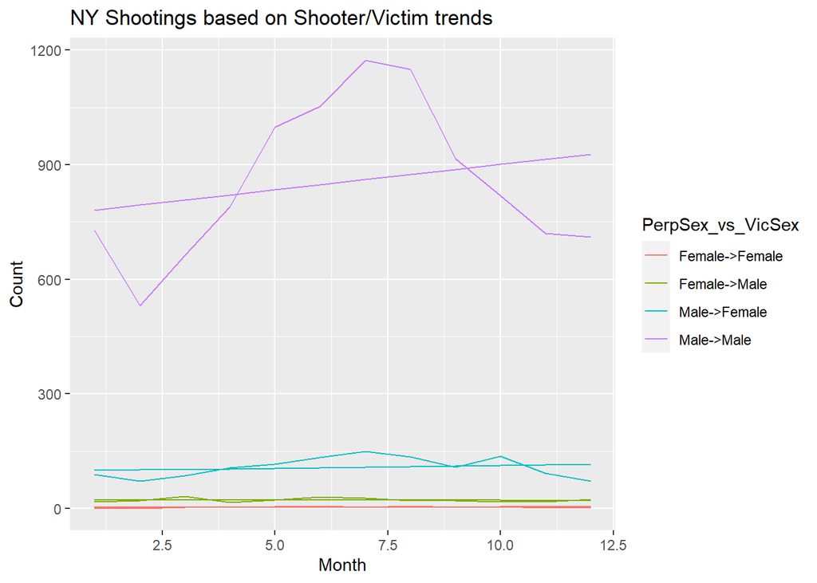

```r
countPerMonth <- filteredCSV %>% count(MONTH, PerpSex_vs_VicSex)
model <- glm(n ~ PerpSex_vs_VicSex / MONTH, data = countPerMonth)
countPerMonth <- countPerMonth %>% mutate(prediction = predict(model))
countPerMonth %>% ggplot() +
    geom_line(aes(x=MONTH, y=n, color = PerpSex_vs_VicSex)) +
    geom_line(aes(x=MONTH, y=prediction, color = PerpSex_vs_VicSex)) +
    labs(title = "NY Shootings based on Shooter/Victim trends", fill = "Perp->Vitim") +
    ylab("Count") + xlab("Month")
```

#### Question 3:

What age groups was the shooter in relative to the victim?

#### Hypothesis 3:

- If a shooting is reported by/to the NYPD, the age groups of shooter and victims will most likely be the same, with the lowest incidence of victims being older than the shooter.

#### Distribution of Shootings Across Age/Sex groups:

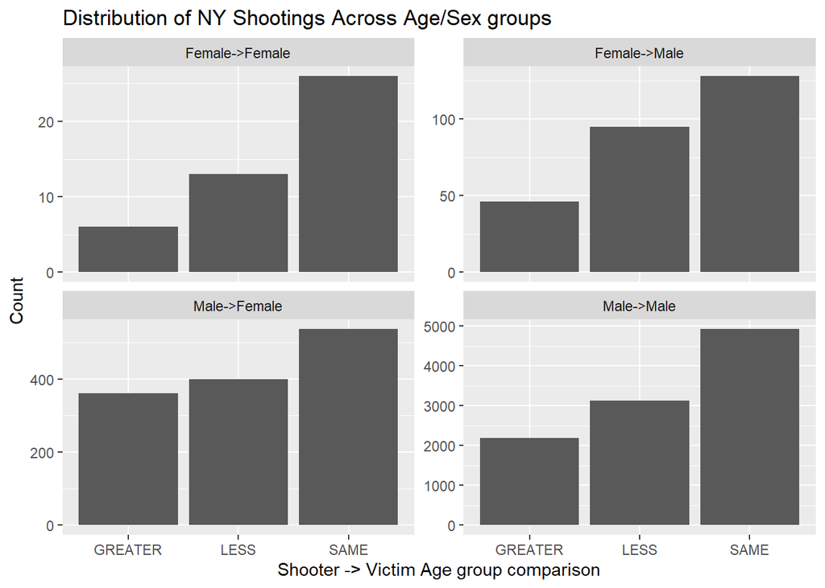

```r
ggplot(data = filteredCSV, mapping = aes(x=Perp_vs_Vic)) +
  facet_wrap(~PerpSex_vs_VicSex, scales = 'free_y') +
  geom_bar(stat="count") +
  labs(title = "Distribution of NY Shootings Across Age/Sex groups") +
  ylab("Count") + xlab("Shooter -> Victim Age group comparison")
```

## Analysis

#### Additional Questions

- Is there any variability with time of day?
- Is there any variability with time of year?
- Did the perpetrator and victim know each other? Were they family? Were they in a relationship? How many were suspected to be related to organized crime? (See if we can further contextualize the violence to provide insights)
- Given larger sample sizes for shootings other than Male -> Male, what trends emerge over the course of a year? Would they be similar to the parabolic trend in the Male -> Male case?
- How many of the reported shootings are reported by the NYPD vs to the NYPD from the public? If there is a large disparity between the two, could that be a source of bias?
- How many shootings take place that are not reported by/to the NYPD? Why? Would those missed sample adversely affect the findings in the current data set?

## Conclusion

For the first research question, the hypothesis was shown to be at least half wrong based on this data set. There was significantly more male shooters than female. However, there was a significant difference between the two victim demographics. Most reported shootings took place between two male subjects, with female victims being a distant second. I found it quite surprising how far apart the differences between Male->Male and Male->Female aggregates was. I was expecting results that were much more comparable.

For the second research question, the hypothesis was wrong for Male->Male shootings and not disproved for all other groupings. I think that the sample sizes for all cases that were not in the Male->Male group were too small to really manifest any real trends and probably has an oversampling bias. As for the Male->Male group, we see peaks in the summer months, and troughs in the fall/winter months. My follow on hypothesis as to why the peaks and troughs where they are, for the much larger sample size group, is that more shootings occur in the summer because more people are out socializing and interacting vs winter which has the opposite effect. Less interactions leads to less opportunities for conflict between people with guns.

A source of bias that could skew the results of all the graphs is uneven reporting of shootings. Without knowing the source of shooting reports, it is difficult contextualize these analyses. For example, if most reports were done by police and were mostly sampled from organized crime, there would potentially be over sampling of Male to Male shootings. (Based on some surveys from a few searches, most gang or crime group members are male. To further complicate things, these sources also have their own implicit bias obviously)

One way I tried to address my bias about these analyses is to make any possible bias (such as availability and confirmation bias) I may have and think of into hypothesis. By framing these ideas as hypothesis anyone can approach them the same that is approached in the scientific process. It is easy to disprove a hypothesis, and difficult to uphold it across many contexts and tests.